# OCTA Repeatability & Reliability — Messy Data — Old Analysis

Bruce Burkemper and Dom Grisafe

2019-11-18

# Load Data

This data was taken from two disparate datasets in Septembter 2019. This is preliminary.

## Jae’s Data

Want to only include observations with both intra-visit and inter-visit measurements so can publish a single paper, with a single Table 1. This was not possible with Ryuna’s data, but it looks like there is sufficient overlap to achieve this in Jae’s data.

| cohort | n_eyes |
| --- | --- |
| **Number of eyes with intra-visit, inter-visit, or both measurements** |  |
| intra only | 30 |
| inter only | 19 |
| both | 206 |

## Ryuna’s Data

Use the readxl package to load select sheets from the excel file.

# Data Wrangling

Remove the row of missing values. Format the variables as double, character, or factors. Then add variable labels.

Note, warnings have been supressed because coercion to NA occurs several times.

## Single Eye Participation

Venugopal (2019) et al. runs the analysis including all eyes. Then they re-ran the analysis after selecting only a single eye randomly from each individual. They conclude minimal difference in the findings, and they report only the analysis that includes all eyes:

“The entire analysis was repeated considering one eye per subject (one eye was randomly chosen from subjects contributing both eyes for the primary analysis) and all the results were similar to the primary analysis.” (Venugopal 2019)

This chunk creates a new dataset that randomly selects a single eye from each individual.

# Table 1: Summary Statistics

Variables stratified by glaucoma status (none, mild, moderate, severe). The Venugopal papers dichotomize glaucoma, but it’s interesting too look at the higher resolution for now.

## Intra-Visit OCTA Summary Statistics

Variables in intra-visit dataset, stratified by glaucoma

|  | None | Mild | Moderate | Severe | p | test |
| --- | --- | --- | --- | --- | --- | --- |
| n | 306 | 44 | 14 | 12 |  |  |
| **Sociodemographics** |  |  |  |  |  |  |
| Age (mean (SD)) | 41.12 (17.18) | 54.45 (17.32) | 63.71 (9.84) | 55.17 (11.43) | <0.001 |  |
| Sex = Male (%) | 150 (49.0) | 24 (54.5) | 6 (42.9) | 10 (83.3) | 0.109 |  |
| Eye laterality = Right Eye (%) | 166 (54.2) | 18 (40.9) | 4 (28.6) | 4 (33.3) | 0.060 |  |
| **Systemic Clinical Measures** |  |  |  |  |  |  |
| Hypertension = Hypertension (%) | 46 (15.0) | 14 (31.8) | 4 (28.6) | 6 (50.0) | 0.001 |  |
| Diabetes mellitus = Diabetes (%) | 10 ( 3.3) | 4 ( 9.1) | 2 (14.3) | 2 (16.7) | 0.020 |  |
| **Ophthalmic Clinical Measures** |  |  |  |  |  |  |
| Intraocular Pressure (mmHg) (mean (SD)) | 14.81 (3.64) | 15.02 (4.79) | 13.57 (2.06) | 13.33 (4.58) | 0.342 |  |
| Central corneal thickness (µm) (mean (SD)) | 560.92 (39.29) | 559.18 (38.09) | 547.14 (37.47) | 546.17 (28.56) | 0.358 |  |
| Cup to disc ratio (mean (SD)) | 0.58 (0.18) | 0.71 (0.17) | 0.76 (0.16) | 0.92 (0.07) | <0.001 |  |
| Mean deviation (dB) of visual field loss (mean (SD)) | -0.86 (1.56) | -1.41 (1.45) | -5.72 (2.84) | -18.02 (11.73) | <0.001 |  |
| Pattern standard deviation (dB) (mean (SD)) | 1.86 (0.92) | 2.27 (1.00) | 5.81 (4.08) | 9.13 (4.97) | <0.001 |  |
| **OCTA Measures** |  |  |  |  |  |  |
| Signal strength (%) |  |  |  |  | 0.001 |  |
| 10 | 214 (69.9) | 25 (56.8) | 7 (50.0) | 6 (50.0) |  |  |
| 9 | 68 (22.2) | 14 (31.8) | 2 (14.3) | 5 (41.7) |  |  |
| 8 | 21 ( 6.9) | 5 (11.4) | 3 (21.4) | 1 ( 8.3) |  |  |
| 7 | 3 ( 1.0) | 0 ( 0.0) | 2 (14.3) | 0 ( 0.0) |  |  |
| Difference in signal strength between measurements (mean (SD)) | 0.25 (0.48) | 0.36 (0.49) | 0.57 (0.51) | 0.50 (0.52) | 0.023 |  |
| Vessel area density (units?) (mean (SD)) | 0.37 (0.04) | 0.32 (0.06) | 0.26 (0.07) | 0.23 (0.03) | <0.001 |  |
| Mean flow intensity in vessel area (units?) (mean (SD)) | 0.11 (0.02) | 0.09 (0.02) | 0.07 (0.02) | 0.06 (0.01) | <0.001 |  |
| Perfusion (units?) (mean (SD)) | 0.43 (0.02) | 0.41 (0.03) | 0.39 (0.02) | 0.35 (0.03) | <0.001 |  |
| Flow index (units?) (mean (SD)) | 0.37 (0.02) | 0.34 (0.04) | 0.30 (0.03) | 0.30 (0.02) | <0.001 |  |

## Inter-Visit OCTA Summary Statistics

Variables in inter-visit dataset, stratified by glaucoma

|  | None | Mild | Moderate | Severe | p | test |
| --- | --- | --- | --- | --- | --- | --- |
| n | 38 | 36 | 12 | 24 |  |  |
| **Sociodemographics** |  |  |  |  |  |  |
| Age (mean (SD)) | 52.71 (14.69) | 52.89 (15.10) | 56.67 (16.55) | 57.50 (12.58) | 0.525 |  |
| Sex = Male (%) | 12 (31.6) | 22 (61.1) | 2 (16.7) | 18 (75.0) | <0.001 |  |
| Eye laterality = Right Eye (%) | 24 (63.2) | 14 (38.9) | 4 (33.3) | 12 (50.0) | 0.127 |  |
| **Systemic Clinical Measures** |  |  |  |  |  |  |
| Hypertension = Hypertension (%) | 10 (26.3) | 6 (16.7) | 4 (33.3) | 8 (33.3) | 0.447 |  |
| Diabetes mellitus = Diabetes (%) | 4 (10.5) | 0 ( 0.0) | 2 (16.7) | 8 (33.3) | 0.002 |  |
| **Ophthalmic Clinical Measures** |  |  |  |  |  |  |
| Intraocular Pressure (mmHg) (mean (SD)) | 13.95 (2.70) | 17.61 (7.11) | 13.08 (4.17) | 12.50 (7.76) | 0.005 |  |
| Central corneal thickness (µm) (mean (SD)) | 540.32 (48.70) | 568.94 (40.15) | 512.83 (24.89) | 530.91 (32.80) | <0.001 |  |
| Cup to disc ratio (mean (SD)) | 0.57 (0.17) | 0.66 (0.24) | 0.83 (0.08) | 0.92 (0.08) | <0.001 |  |
| Mean deviation (dB) of visual field loss (mean (SD)) | -0.71 (2.16) | -1.07 (1.54) | -6.66 (2.41) | -16.45 (6.86) | <0.001 |  |
| Pattern standard deviation (dB) (mean (SD)) | 2.41 (2.01) | 2.68 (1.45) | 5.40 (2.25) | 12.02 (3.20) | <0.001 |  |
| **OCTA Measures** |  |  |  |  |  |  |
| Signal strength (%) |  |  |  |  | 0.116 |  |
| 10 | 20 (52.6) | 14 (38.9) | 3 (25.0) | 7 (29.2) |  |  |
| 9 | 12 (31.6) | 16 (44.4) | 3 (25.0) | 10 (41.7) |  |  |
| 8 | 6 (15.8) | 5 (13.9) | 5 (41.7) | 4 (16.7) |  |  |
| 7 | 0 ( 0.0) | 1 ( 2.8) | 1 ( 8.3) | 3 (12.5) |  |  |
| Difference in signal strength between measurements (mean (SD)) | 0.42 (0.50) | 0.94 (0.71) | 1.00 (0.85) | 0.58 (0.65) | 0.002 |  |
| Vessel area density (units?) (mean (SD)) | 0.34 (0.04) | 0.31 (0.06) | 0.25 (0.06) | 0.21 (0.03) | <0.001 |  |
| Mean flow intensity in vessel area (units?) (mean (SD)) | 0.10 (0.02) | 0.09 (0.02) | 0.07 (0.02) | 0.05 (0.01) | <0.001 |  |
| Perfusion (units?) (mean (SD)) | 0.42 (0.02) | 0.40 (0.03) | 0.39 (0.03) | 0.34 (0.02) | <0.001 |  |
| Flow index (units?) (mean (SD)) | 0.35 (0.03) | 0.33 (0.03) | 0.30 (0.04) | 0.29 (0.02) | <0.001 |  |

# Signal Strength

After speaking with GR on 8/28/2019, it seems like signal strength will have to be included in the linear mixed-effect regression models.

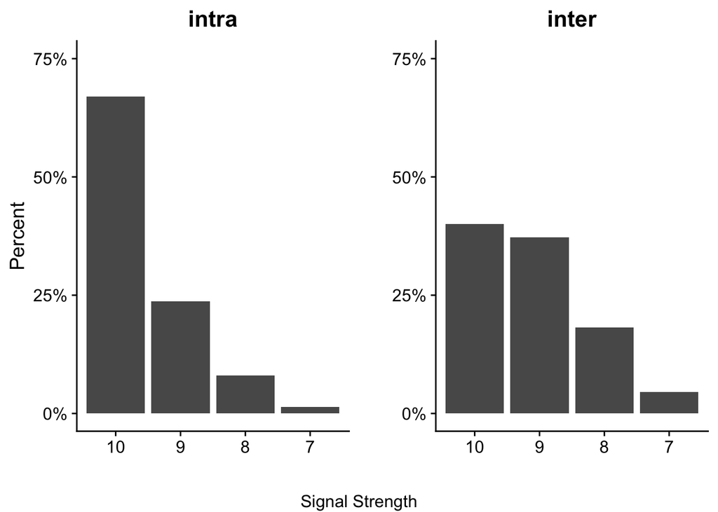

# OCTA Variables by Signal Strength

## Intra-Visit OCTA Variables by Signal Strength

Intravisit mean OCTA variables by signal strength (7-10)

| Signal Strength SS | Signal Strength n | VAD Mean | VAD % Diff | FLUX Mean | FLUX % Diff | PF Mean | PF % Diff | FI Mean | FI % Diff |
| --- | --- | --- | --- | --- | --- | --- | --- | --- | --- |
| 10 | 252 | 0.368 | 0.0% | 0.112 | 0.0% | 0.434 | 0.0% | 0.367 | 0.0% |
| 9 | 89 | 0.332 | -9.9% | 0.097 | -13.2% | 0.421 | -2.8% | 0.344 | -6.2% |
| 8 | 30 | 0.306 | -16.8% | 0.088 | -21.8% | 0.405 | -6.6% | 0.333 | -9.2% |
| 7 | 5 | 0.252 | -31.7% | 0.069 | -38.5% | 0.404 | -6.8% | 0.305 | -16.9% |

## Inter-Visit OCTA Variables by Signal Strength

Intervisit mean OCTA variables by signal strength (7-10)

| Signal Strength SS | Signal Strength n | VAD Mean | VAD % Diff | FLUX Mean | FLUX % Diff | PF Mean | PF % Diff | FI Mean | FI % Diff |
| --- | --- | --- | --- | --- | --- | --- | --- | --- | --- |
| 10 | 44 | 0.329 | 0.0% | 0.096 | 0.0% | 0.408 | 0.0% | 0.345 | 0.0% |
| 9 | 41 | 0.279 | -15.3% | 0.077 | -19.1% | 0.395 | -3.2% | 0.318 | -7.9% |
| 8 | 20 | 0.265 | -19.4% | 0.072 | -25.1% | 0.377 | -7.6% | 0.313 | -9.4% |
| 7 | 5 | 0.194 | -41.2% | 0.045 | -53.0% | 0.348 | -14.8% | 0.274 | -20.6% |

# Exploratory Data Analysis

## Scatter Plots of OCTA Variables by Subject ID

Scatter plots of OCTA variables for about 10 individuals randomly sampled. These are separated by intra- and inter-visit datasets, and are useful for understanding the data better.

### VAD

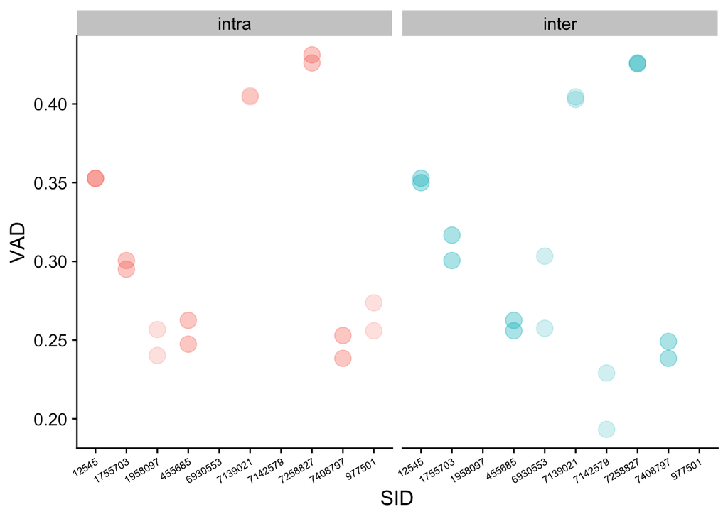

### FLUX

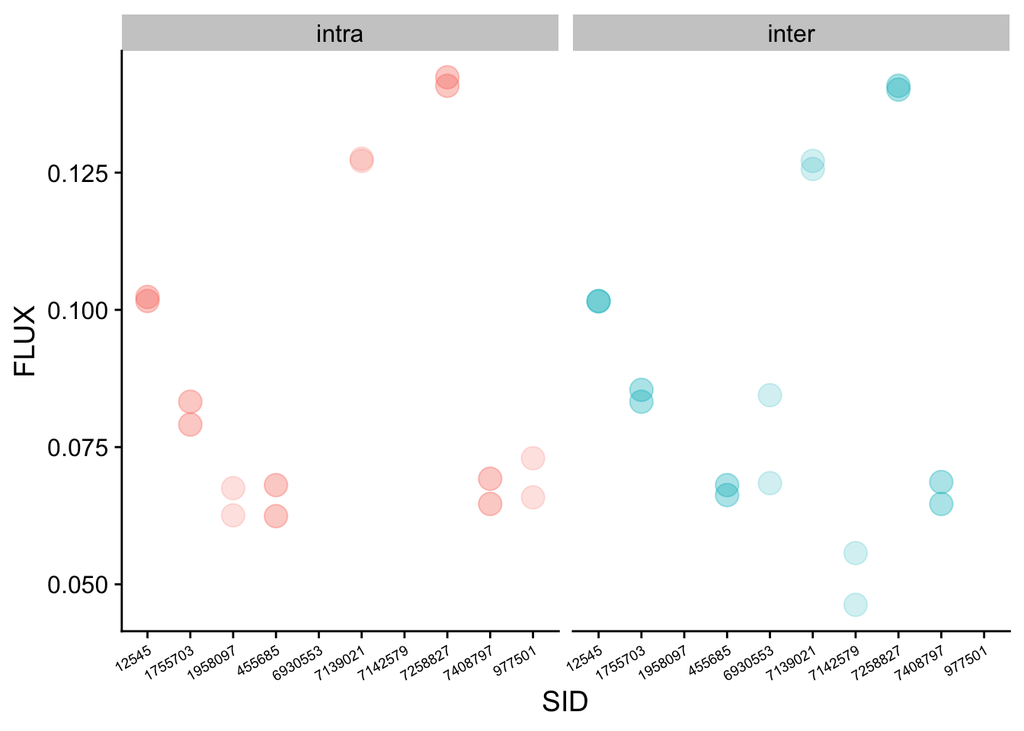

### PF

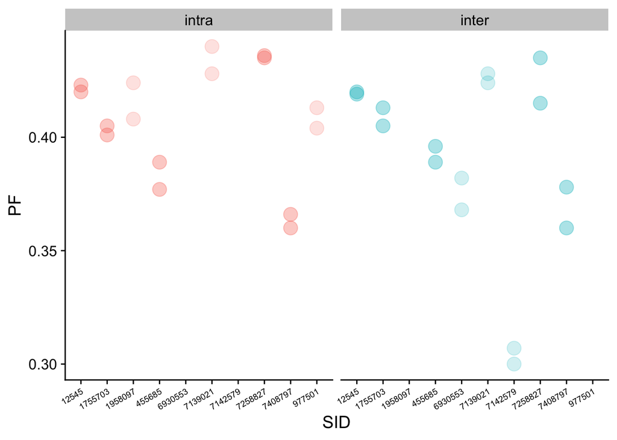

### FI

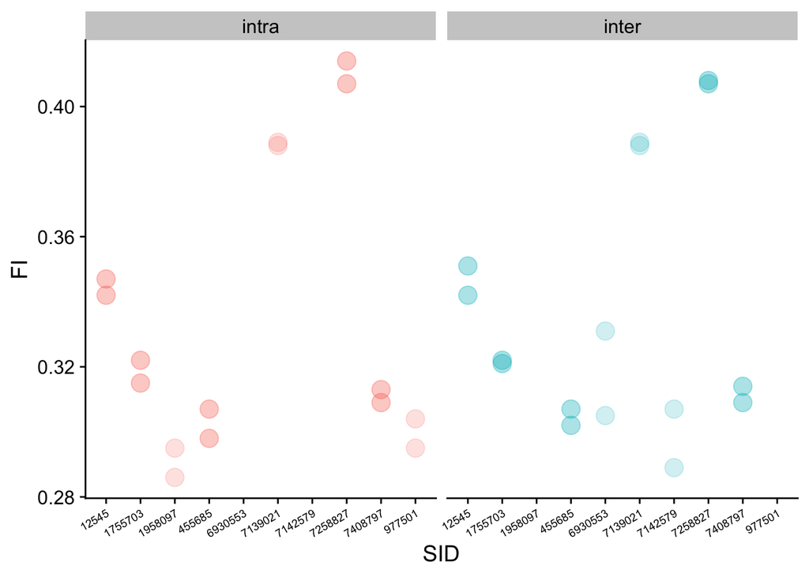

## Spaghetti Plots of OCTA Variables

Spaghetti plots of OCTA variables for about 10 individuals randomly sampled. Mean is superimposed on top in dotted, red line.

### VAD

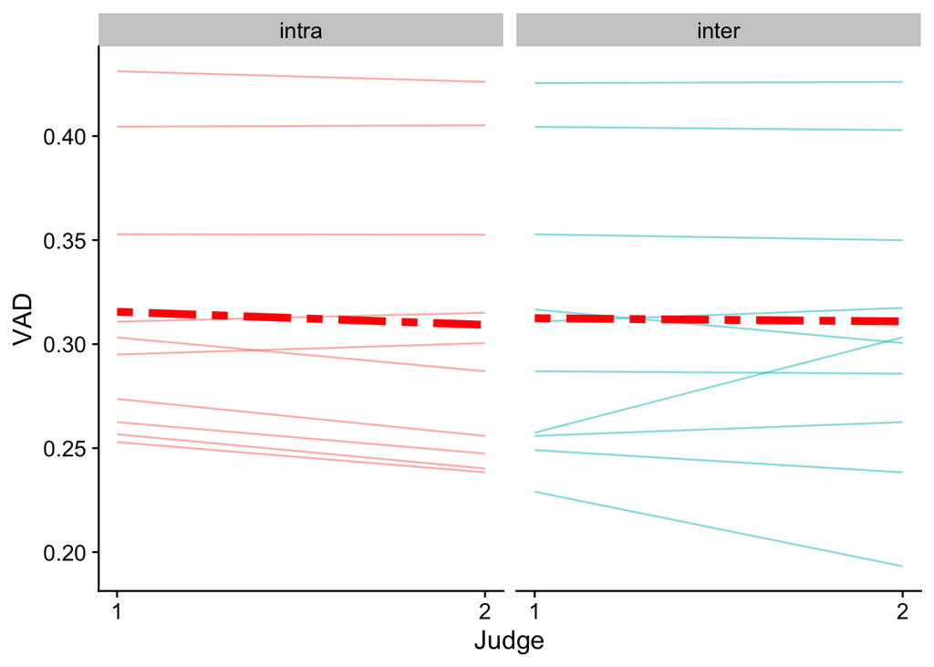

### FLUX

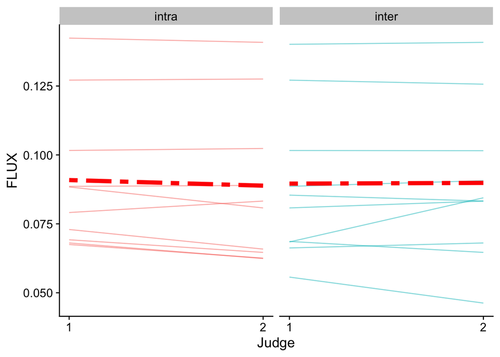

### PF

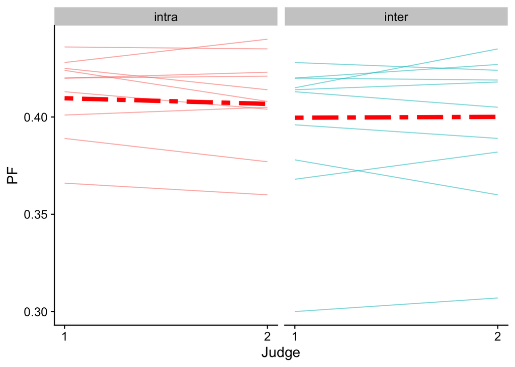

### FI

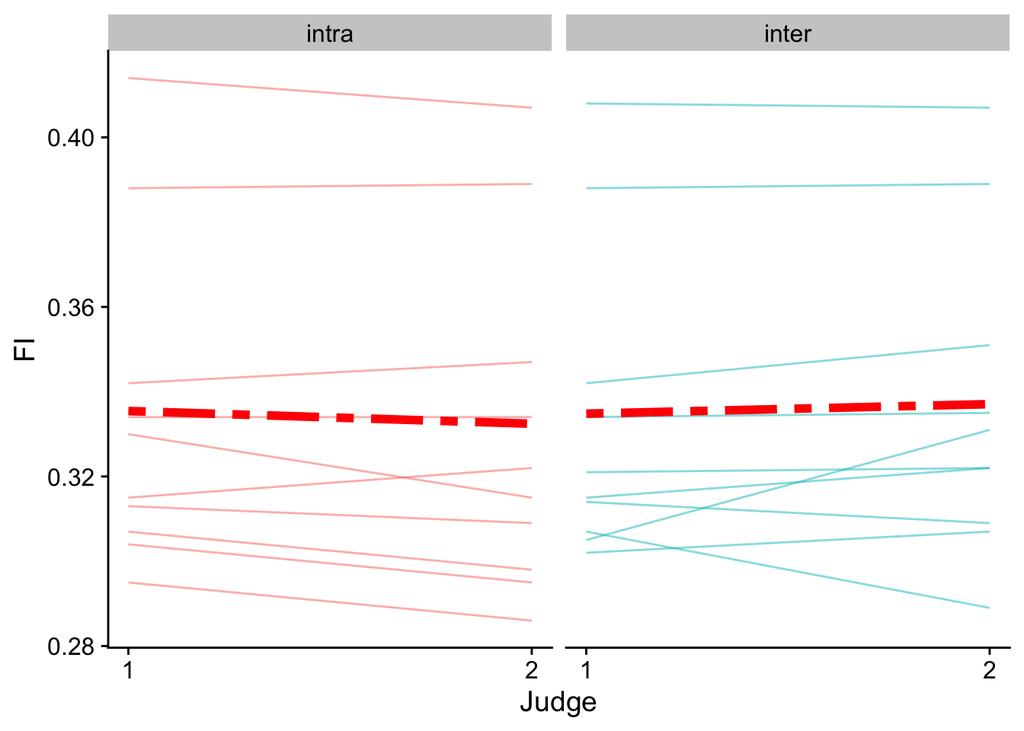

# Bland-Altman Plots of OCTA Variables

Coding of Bland-Altman plots is explained in this [blog post](https://www.r-bloggers.com/bland-altmantukey-mean-difference-plots-using-ggplot2/).

## Intra-Visit Bland-Altman Plots of OCTA Variables

### VAD

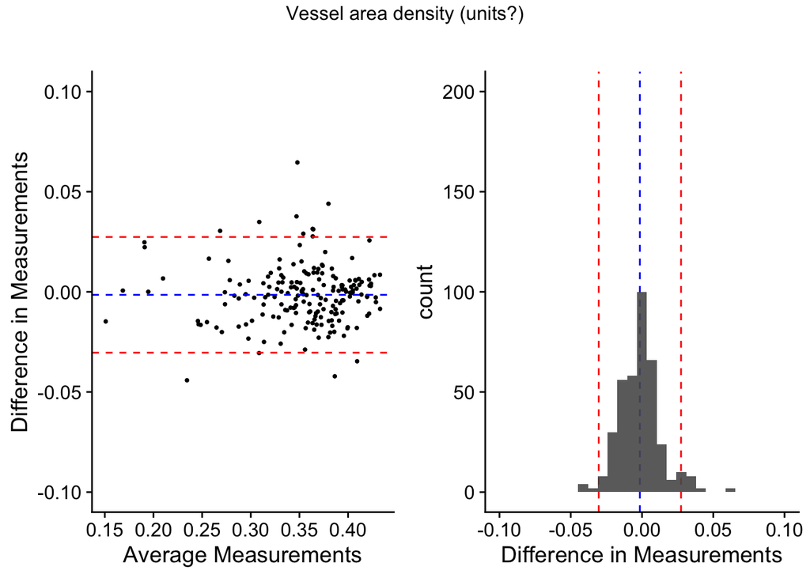

### FLUX

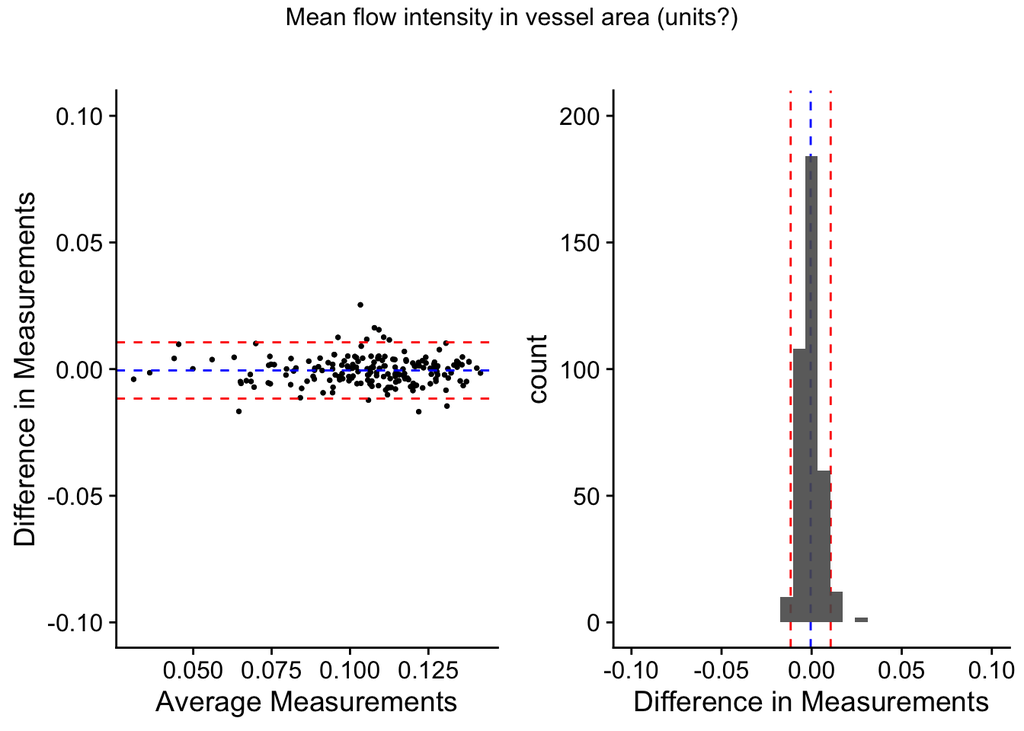

### PF

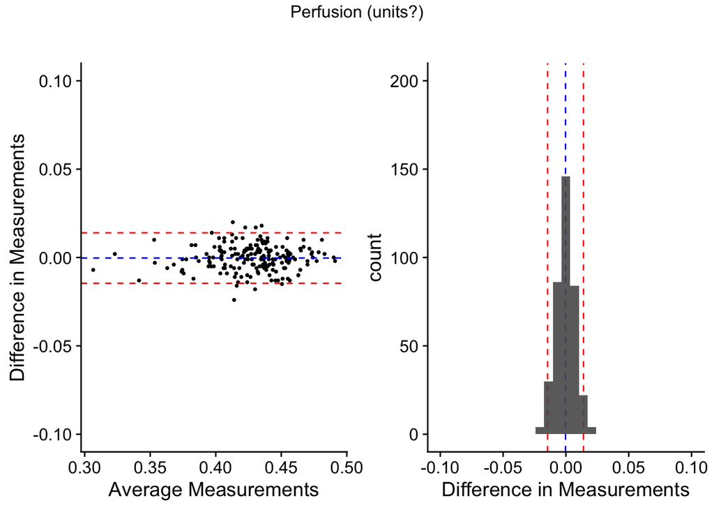

### FI

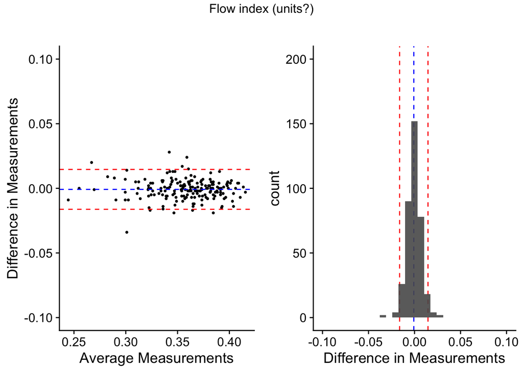

## Inter-Visit Bland-Altman Plots of OCTA Variables

### VAD

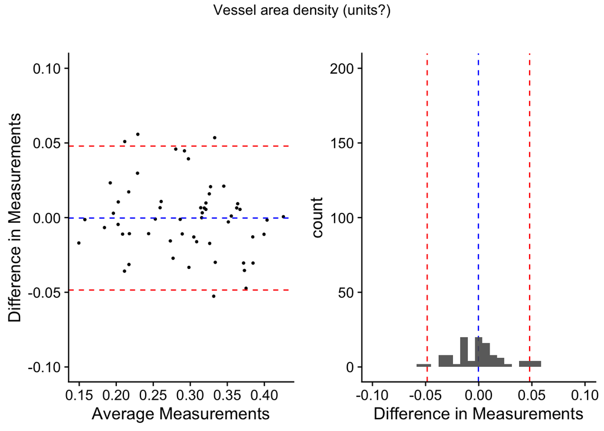

### FLUX

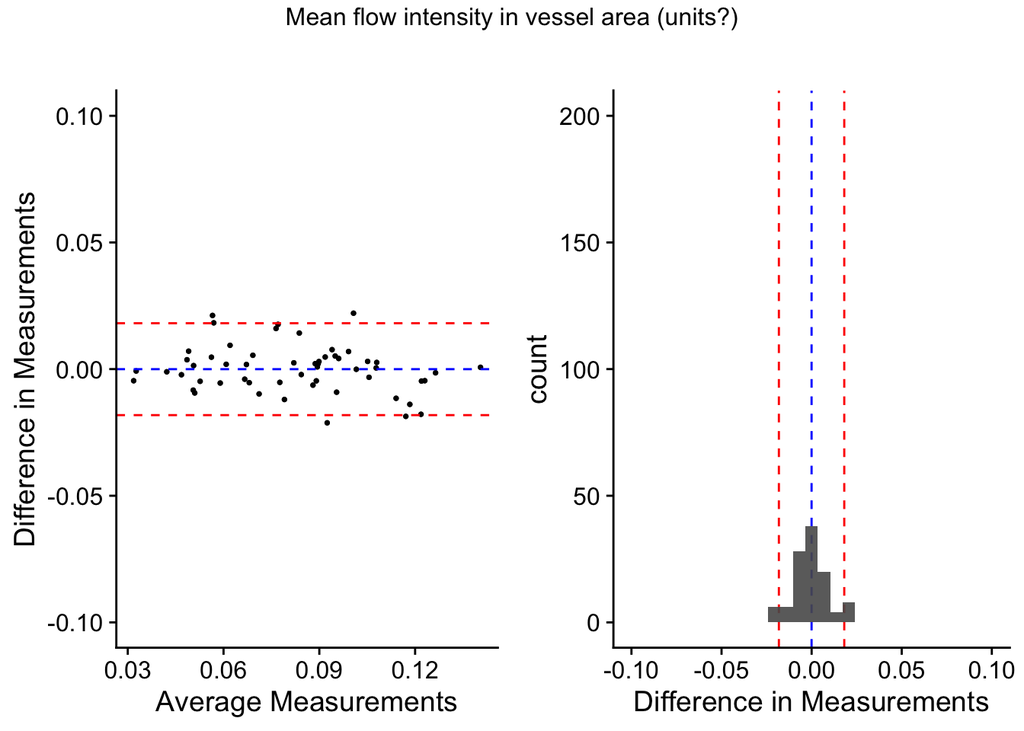

### PF

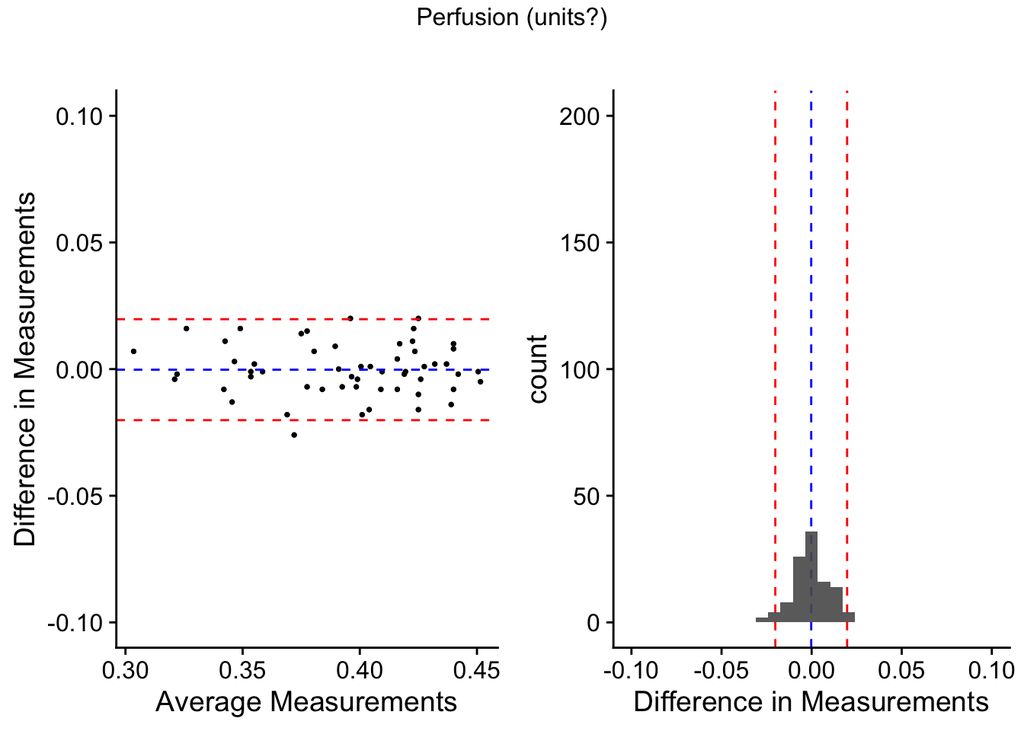

### FI

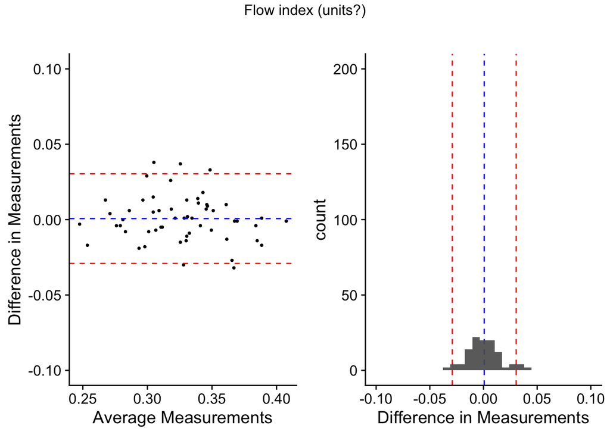

# Intra-Visit Repeatability of OCTA Variables

Calculate the within-subject standard deviation $(S_w)$, the within-subject coefficient of repeatability $(CR_w)$, and the within-subject coefficient of variation $(CV_w)$ for a given measurement variable $x$.

## Table 2: Repeatability estimates of vessel density measurements

This table was modeled after Table 2 in Venugopal (2018). They stratified these values by dichotomous glaucoma status, but we’re not sure if that is appropriate.

| octa_var | µ | Sw | CRw | CVw |
| --- | --- | --- | --- | --- |
| Vessel area density (units?) | 0.353 | 0.010 | 0.029 | 2.962 |
| Mean flow intensity in vessel area (units?) | 0.106 | 0.004 | 0.011 | 3.795 |
| Perfusion (units?) | 0.428 | 0.005 | 0.014 | 1.203 |
| Flow index (units?) | 0.358 | 0.006 | 0.015 | 1.560 |

I still need to figure out how they calculated the 95% CIs, which I think is just $1.96*\sqrt{SE}$ because they all appear symmetric, but I’m not sure yet. Then I need to stratify these stats by glaucoma diagnosis (yes/no). - DG 8/29/2019

Bruce showed me a paper that has the calculation of the confidence intervals. It’s not difficult to manually code them, just need to read the paper. - DG 9/4/2019

## Calculating repeatability statistics

Explanations of repeatability statistic calculations

### Within-subject mean $(\mu_w)$

$\mu_w$ is the average measurement of both eyes for each individual. The overall mean $(\mu)$ is calculated by taking the mean of $\mu_w$ across the dataset. The overall mean is included in the final table for reference.

$$\mu_w = \frac{1}{M}\sum_{i=1}^{M} x_i$$

$$\text{where } M \text{ is the number of measurements per eye,}$$

### Within-subject standard deviation $(S_w)$

Find $S_w$ by first calculating the variance of the measurements per individual eye. The equation below is general for any number of measurements, but in this study there are only 2 measurements per eye.

$$\sigma^2_{measurement} = \frac{1}{M}\sum_{i=1}^{M} (x_i - \mu_w)^2$$

$$\text{where } M \text{ is the number of measurements per eye}$$

To calculate $S_w$, average of the variance of measurements $(\sigma^2_{measurement})$ for all eyes measured, then take the square root.

$$Sw = \sqrt{\frac{1}{N}\sum_{i=1}^{N}\sigma^2_{measurement,i}}$$

$$\text{where } N \text{ is the number of eyes measured}$$

### Within-subject coefficient of repeatability $(CR_w)$

The $CR_w$ provides the uncertainty of repeated measures.

$$CRw = \sqrt2 * 1.96 * Sw$$

The $CR_w$ can be interpreted as:

“The difference between two measurements for the same subject is expected to be less than [$CR_w$] for 95% of pairs of observations.” (Bland 1996)

### Within-subject coefficient of variation $(CV_w)$

$$CVw = 100 *\frac{Sw}{\mu}$$

# Intraclass Correlation Coefficient (ICC)

## Intra-Visit OCTA ICC

| V1 | ICC | LowerCI | UpperCI | N | k | varw | vara |
| --- | --- | --- | --- | --- | --- | --- | --- |
| VAD | 0.972 | 0.961 | 0.981 | 123 | 2 | 9.18466783975707e-05 | 0.00322598565540887 |
| FLUX | 0.973 | 0.962 | 0.981 | 123 | 2 | 1.37767371481488e-05 | 0.00050242975831156 |
| PF | 0.970 | 0.957 | 0.979 | 123 | 2 | 2.88699186991857e-05 | 0.000923063074770091 |
| FI | 0.976 | 0.966 | 0.983 | 123 | 2 | 2.59512195121952e-05 | 0.00106387804878049 |

## Inter-Visit OCTA ICC

| V1 | ICC | LowerCI | UpperCI | N | k | varw | vara |
| --- | --- | --- | --- | --- | --- | --- | --- |
| VAD | 0.938 | 0.887 | 0.967 | 40 | 2 | 0.000304097413869599 | 0.00461893331564824 |
| FLUX | 0.942 | 0.893 | 0.969 | 40 | 2 | 4.14977849092933e-05 | 0.000669942171179661 |
| PF | 0.965 | 0.936 | 0.981 | 40 | 2 | 5.34750000000001e-05 | 0.00148912083333333 |
| FI | 0.918 | 0.851 | 0.955 | 40 | 2 | 0.000108325 | 0.00120806506410256 |

## Calculating ICC Statistic

$$\text{ICC} = \frac{\text{between}}{\text{between} + \text{within}}$$

“In the output for the random effects model ‘SID’ is the estimated between-group variance, which in the ICCest output is called ‘vara’ (variance among groups). The within-group variance is ‘Residual’ in the random effects model output, while in ICCest it’s called ‘varw.’ You can see that the values for those two variances match perfectly in the two different outputs. The ICC is defined as between/(between+within). That calculation is not part of the random effects model output, but it is part of the ICCest output, along with confidence intervals for the ICC estimate. The ICCs are really high for intravisit (around 97%) and a little lower for intervisit (about 94%). If we were to calculate these ICCs for glaucoma and controls separately I think they would be significantly lower because of the reduced between-group variability.” - BB 9/4/2019

# Mixed Effects Regression Models

## Model Fitting

“For the markdown file let’s just spit out all the output from the random effects model and the iccest command so we can show it to Grace. Eventually we can put the ICCs in the table with the other repeatability measures you have already tabled but I don’t think we need it for the meeting. I also added a model to test whether SS influences reliability. The reference level is ‘10’ now, which is what we want, and you can see that SS is highly associated with VAD, meaning it affects reliability.” - BB 9/4/2019

```r
model1.fit <- lmer(VAD ~ (1|SID), data=data_octa_intra_1eye)
summary(model1.fit)
```

```
## Linear mixed model fit by REML ['lmerMod']
## Formula: VAD ~ (1 | SID)
##    Data: data_octa_intra_1eye
##
## REML criterion at convergence: -1056.1
##
## Scaled residuals:
##     Min      1Q  Median      3Q     Max
## -2.2531 -0.4127  0.0006  0.4207  2.3369
##
## Random effects:
##  Groups   Name        Variance  Std.Dev.
##  SID      (Intercept) 3.226e-03 0.056798
##  Residual             9.185e-05 0.009584
## Number of obs: 246, groups:  SID, 123
##
## Fixed effects:
##             Estimate Std. Error t value
## (Intercept) 0.351204   0.005158   68.09
```

```r
model2.fit <- lmer(VAD ~ SS + (1|SID), data=data_octa_intra_1eye)
summary(model2.fit)
```

```
## Linear mixed model fit by REML ['lmerMod']
## Formula: VAD ~ SS + (1 | SID)
##    Data: data_octa_intra_1eye
##
## REML criterion at convergence: -1088.3
##
## Scaled residuals:
##      Min       1Q   Median       3Q      Max
## -2.63461 -0.40672 -0.02084  0.39521  2.69790
##
## Random effects:
##  Groups   Name        Variance  Std.Dev.
##  SID      (Intercept) 2.754e-03 0.052481
##  Residual             6.805e-05 0.008249
## Number of obs: 246, groups:  SID, 123
##
## Fixed effects:
##              Estimate Std. Error t value
## (Intercept)  0.358433   0.004853  73.861
## SS9         -0.017636   0.002672  -6.599
## SS8         -0.031583   0.005053  -6.250
## SS7         -0.049635   0.007708  -6.440
##
## Correlation of Fixed Effects:
##     (Intr) SS9    SS8
## SS9 -0.171
## SS8 -0.162  0.499
## SS7 -0.104  0.328  0.485
```